# Demographics and Poverty in The United States

By: Dmitri Kontchaev

## Introduction

#### The Data Science Pipeline

In today's era of information abundance, data is being generated at an unprecedented rate, transforming the way we approach problem-solving and decision-making. Data science allows us to extract valuable insights and make informed decisions from this seemingly endless data. However, the process to doing so is involved and not without risks, as providing innaccurate analysis of data can lead to misiniformation. This project aims to showcase the entire data science pipeline. This can be characterized by four main steps:

1. Data curation and processing
2. Exploratory data analysis
3. Hypothesis testing and machine learning
4. Interpretation and insights

In this project I will showcase these steps by looking at the United States in terms of racial minority populations and poverty.

#### Why demographics and poverty?

Understanding the demographic composition of different regions is vital for many reasons. Racial demographics influence various aspects of society, including social dynamics, public policies, and economic opportunities. Analyzing this data at a county-level allows us to gain a nuanced perspective on how different racial groups are distributed across the United States, shedding light on regional disparities and potential inequalities. By combining this information with poverty data, we can uncover potential relationships and identify specific racial groups which might be disproportionately affected by poverty.

## Step 1: Data curation and processing

There are three important datasets used in this project. The first provides information about the population of the United States broken down by age groups, race, and county from 2010 to 2020. The second provides economic information about these counties. Specifically, it provides information about household income and poverty levels. Both of these datasets come from the United States Census Bureau. The United States Census Bureau is a governemnt organization which is responsible for collecting and producing data about the American People and the economy. The third dataset is a JSON file which provides geographic information about the counties. This dataset is from plotly, a python library, and will allow us to create maps with the data.

#### Data curation

Fortunately, all of these datasets come in a form which is directly accessible or downloadable, so we will not need to scrape HTML content in order to get our data.

- [Demographic Data](https://www.census.gov/programs-surveys/popest/technical-documentation/research/evaluation-estimates/2020-evaluation-estimates/2010s-county-detail.html)
- [Economic Data](https://www.census.gov/data/datasets/2020/demo/saipe/2020-state-and-county.html)
- [Geographic Data](https://github.com/plotly/datasets/blob/master/geojson-counties-fips.json)

#### Data processing

We begin by importing all of the necessarry libraries for this analysis:

```python
import pandas as pd
from urllib.request import urlopen
import json
import plotly.express as px
import statsmodels.api as sm
import statsmodels.formula.api as smf
import numpy as np
import matplotlib.pyplot as plt
from sklearn import linear_model
from sklearn.impute import KNNImputer
from sklearn.ensemble import RandomForestClassifier
from sklearn.linear_model import LinearRegression
from sklearn import preprocessing
```

**Load in geographic data**

```python
with urlopen('https://raw.githubusercontent.com/plotly/datasets/master/geojson-counties-fips.json') as response:
    counties = json.load(response)
```

**Load in demographic data**

```python
df = pd.read_csv("CC-EST2020-ALLDATA.csv", encoding='latin-1', low_memory=False)
df.head()
```

|  | SUMLEV | STATE | COUNTY | STNAME | CTYNAME | YEAR | AGEGRP | TOT_POP | TOT_MALE | TOT_FEMALE | ... | HWAC_MALE | HWAC_FEMALE | HBAC_MALE | HBAC_FEMALE | HIAC_MALE | HIAC_FEMALE | HAAC_MALE | HAAC_FEMALE | HNAC_MALE | HNAC_FEMALE |
| --- | --- | --- | --- | --- | --- | --- | --- | --- | --- | --- | --- | --- | --- | --- | --- | --- | --- | --- | --- | --- | --- |
| 0 | 50 | 1 | 1 | Alabama | Autauga County | 1 | 0 | 54571 | 26569 | 28002 | ... | 607 | 538 | 57 | 48 | 26 | 32 | 9 | 11 | 19 | 10 |
| 1 | 50 | 1 | 1 | Alabama | Autauga County | 1 | 1 | 3579 | 1866 | 1713 | ... | 77 | 56 | 9 | 5 | 4 | 1 | 0 | 0 | 2 | 1 |
| 2 | 50 | 1 | 1 | Alabama | Autauga County | 1 | 2 | 3991 | 2001 | 1990 | ... | 64 | 66 | 2 | 3 | 2 | 7 | 2 | 3 | 2 | 0 |
| 3 | 50 | 1 | 1 | Alabama | Autauga County | 1 | 3 | 4290 | 2171 | 2119 | ... | 51 | 57 | 13 | 7 | 5 | 5 | 2 | 1 | 1 | 1 |
| 4 | 50 | 1 | 1 | Alabama | Autauga County | 1 | 4 | 4290 | 2213 | 2077 | ... | 48 | 44 | 7 | 5 | 0 | 2 | 2 | 1 | 3 | 1 |

5 rows × 80 columns

In this analysis we will be looking at the year 2020 and focusing on all racial minority groups and not different age groups within these minorities. From looking at the above dataset there are four things we need to do off the bat:

- The years in the dataset do not exactly correspond to the actual year that the data is from. Looking at the [documentaion](https://www2.census.gov/programs-surveys/popest/technical-documentation/file-layouts/2010-2020/cc-est2020-alldata.pdf), we can see that the value 13 corresponds to data from the year 2020, so we must isolate the data from 2020, and update the year value
- In order to use the geographic data, we need to combine the COUNTY and STATE columns which correspond to the county and state's respective Federal Information Processing Standards (FIPS) code
- The dataset is broken down into different age groups. The documentation indicates that age group 0 is the totals from all of the age groups
- Additionally we will apply a conversion to the dataset to try to make all of the values into numeric data types. This will not work for the string values, but it is important for doing transformations with the demographic values later.

```python
df1 = df.copy(deep=True)
df1 = df1.loc[(df["YEAR"] == 13) & (df1["AGEGRP"] == 0)] # Select year 2020 and age group totals

df1 = df1.apply(pd.to_numeric, errors='ignore')
df1.loc[:,'YEAR'] = df1.loc[:,"YEAR"] + 2007
df1.loc[:,'COUNTY'] = df1.loc[:,'COUNTY'].apply(lambda x: '{0:0>3}'.format(x))
df1.loc[:,'STATE'] = df1.loc[:,'STATE'].apply(lambda x: '{0:0>2}'.format(x))
df1.loc[:,'FIPS'] = (df1.STATE.astype(str) + df1.COUNTY.astype(str))
df1
```

|  | SUMLEV | STATE | COUNTY | STNAME | CTYNAME | YEAR | AGEGRP | TOT_POP | TOT_MALE | TOT_FEMALE | ... | HWAC_FEMALE | HBAC_MALE | HBAC_FEMALE | HIAC_MALE | HIAC_FEMALE | HAAC_MALE | HAAC_FEMALE | HNAC_MALE | HNAC_FEMALE | FIPS |
| --- | --- | --- | --- | --- | --- | --- | --- | --- | --- | --- | --- | --- | --- | --- | --- | --- | --- | --- | --- | --- | --- |
| 228 | 50 | 01 | 001 | Alabama | Autauga County | 2020 | 0 | 56145 | 27226 | 28919 | ... | 694 | 107 | 94 | 36 | 27 | 19 | 24 | 16 | 10 | 01001 |
| 475 | 50 | 01 | 003 | Alabama | Baldwin County | 2020 | 0 | 229287 | 111000 | 118287 | ... | 4742 | 279 | 307 | 276 | 214 | 69 | 73 | 57 | 52 | 01003 |
| 722 | 50 | 01 | 005 | Alabama | Barbour County | 2020 | 0 | 24589 | 12987 | 11602 | ... | 422 | 66 | 55 | 62 | 28 | 5 | 2 | 16 | 9 | 01005 |
| 969 | 50 | 01 | 007 | Alabama | Bibb County | 2020 | 0 | 22136 | 11773 | 10363 | ... | 264 | 35 | 22 | 9 | 12 | 7 | 6 | 20 | 3 | 01007 |
| 1216 | 50 | 01 | 009 | Alabama | Blount County | 2020 | 0 | 57879 | 28617 | 29262 | ... | 2459 | 87 | 75 | 72 | 74 | 15 | 17 | 31 | 24 | 01009 |
| ... | ... | ... | ... | ... | ... | ... | ... | ... | ... | ... | ... | ... | ... | ... | ... | ... | ... | ... | ... | ... | ... |
| 775314 | 50 | 56 | 037 | Wyoming | Sweetwater County | 2020 | 0 | 42673 | 22036 | 20637 | ... | 3043 | 97 | 71 | 222 | 188 | 31 | 39 | 18 | 13 | 56037 |
| 775561 | 50 | 56 | 039 | Wyoming | Teton County | 2020 | 0 | 23497 | 12187 | 11310 | ... | 1563 | 31 | 19 | 104 | 87 | 17 | 15 | 17 | 13 | 56039 |
| 775808 | 50 | 56 | 041 | Wyoming | Uinta County | 2020 | 0 | 20215 | 10230 | 9985 | ... | 877 | 29 | 23 | 101 | 130 | 7 | 16 | 8 | 5 | 56041 |
| 776055 | 50 | 56 | 043 | Wyoming | Washakie County | 2020 | 0 | 7760 | 3954 | 3806 | ... | 478 | 12 | 13 | 56 | 55 | 5 | 7 | 5 | 2 | 56043 |
| 776302 | 50 | 56 | 045 | Wyoming | Weston County | 2020 | 0 | 6743 | 3538 | 3205 | ... | 116 | 5 | 6 | 18 | 29 | 3 | 0 | 1 | 1 | 56045 |

3143 rows × 81 columns

Now we will perform some transformations to the data in order to allow us to analyze it. First we create a few new columns. The first new column represents the total minority population in a county. The rest of the new columns represent the minority populations as a percentage of the county's entire population. We do this for the total minority calculation in addition to the five minority populations available:

- Not Hispanic, Black or African American alone
- Not Hispanic, American Indian and Alaska Native alone
- Not Hispanic, Asian alone
- Not Hispanic, Native Hawaiian and Other Pacific Islander alone
- Hispanic

```python
df1["TOT_MIN"] = df1["NHBA_MALE"] + df1["NHBA_FEMALE"] + df1["NHIA_MALE"] + df1["NHIA_FEMALE"] + df1["NHAA_MALE"] + df1["NHAA_FEMALE"] + df1["NHNA_MALE"] + df1["NHNA_FEMALE"] + df1["H_MALE"] + df1["H_FEMALE"]
df1["NHBA_P"] = 100*(df1["NHBA_MALE"] + df1["NHBA_FEMALE"])/df1["TOT_POP"]
df1["NHIA_P"] = 100*(df1["NHIA_MALE"] + df1["NHIA_FEMALE"])/df1["TOT_POP"]
df1["NHAA_P"] = 100*(df1["NHAA_MALE"] + df1["NHAA_FEMALE"])/df1["TOT_POP"]
df1["NHNA_P"] = 100*(df1["NHNA_MALE"] + df1["NHNA_FEMALE"])/df1["TOT_POP"]
df1["H_P"] = 100*(df1["H_MALE"] + df1["H_FEMALE"])/df1["TOT_POP"]
df1["TOT_MINPERC"] = 100*df1["TOT_MIN"]/df1["TOT_POP"]
df1 = df1.loc[:,["FIPS","TOT_POP","TOT_MIN","TOT_MINPERC","NHBA_P","NHIA_P","NHAA_P","NHNA_P","H_P"]]

df1
```

|  | FIPS | TOT_POP | TOT_MIN | TOT_MINPERC | NHBA_P | NHIA_P | NHAA_P | NHNA_P | H_P |
| --- | --- | --- | --- | --- | --- | --- | --- | --- | --- |
| 228 | 01001 | 56145 | 14066 | 25.052988 | 20.318817 | 0.425683 | 1.136343 | 0.071244 | 3.100899 |
| 475 | 01003 | 229287 | 34201 | 14.916240 | 8.478893 | 0.668594 | 1.086847 | 0.047975 | 4.633930 |
| 722 | 01005 | 24589 | 13137 | 53.426329 | 47.809996 | 0.382285 | 0.451421 | 0.109805 | 4.672821 |
| 969 | 01007 | 22136 | 5435 | 24.552765 | 20.979400 | 0.402060 | 0.212324 | 0.027105 | 2.931876 |
| 1216 | 01009 | 57879 | 6900 | 11.921422 | 1.527324 | 0.463035 | 0.350732 | 0.036283 | 9.544049 |
| ... | ... | ... | ... | ... | ... | ... | ... | ... | ... |
| 775314 | 56037 | 42673 | 8142 | 19.079980 | 1.099056 | 0.756919 | 0.904553 | 0.131231 | 16.188222 |
| 775561 | 56039 | 23497 | 4132 | 17.585224 | 0.736264 | 0.370260 | 1.455505 | 0.072350 | 14.950845 |
| 775808 | 56041 | 20215 | 2370 | 11.723967 | 0.568884 | 0.643087 | 0.484789 | 0.123671 | 9.903537 |
| 776055 | 56043 | 7760 | 1237 | 15.940722 | 0.451031 | 0.579897 | 0.747423 | 0.000000 | 14.162371 |
| 776302 | 56045 | 6743 | 527 | 7.815512 | 0.682189 | 1.572001 | 1.438529 | 0.014830 | 4.107964 |

3143 rows × 9 columns

Now we can move onto processing the economic dataset.

```python
dfx = pd.read_excel("est20all.xls")
dfx
```

|  | Table with column headers in rows 3 and 4 | Unnamed: 1 | Unnamed: 2 | Unnamed: 3 | Unnamed: 4 | Unnamed: 5 | Unnamed: 6 | Unnamed: 7 | Unnamed: 8 | Unnamed: 9 | ... | Unnamed: 21 | Unnamed: 22 | Unnamed: 23 | Unnamed: 24 | Unnamed: 25 | Unnamed: 26 | Unnamed: 27 | Unnamed: 28 | Unnamed: 29 | Unnamed: 30 |
| --- | --- | --- | --- | --- | --- | --- | --- | --- | --- | --- | --- | --- | --- | --- | --- | --- | --- | --- | --- | --- | --- |
| 0 | 2020 Poverty and Median Household Income Estim... | NaN | NaN | NaN | NaN | NaN | NaN | NaN | NaN | NaN | ... | NaN | NaN | NaN | NaN | NaN | NaN | NaN | NaN | NaN | NaN |
| 1 | Geographic Information | NaN | NaN | NaN | All Ages | NaN | NaN | NaN | NaN | NaN | ... | NaN | Median Household Income | NaN | NaN | Age 0-4 | NaN | NaN | NaN | NaN | NaN |
| 2 | State FIPS Code | County FIPS Code | Postal Code | Name | Poverty Estimate, All Ages | 90% CI Lower Bound | 90% CI Upper Bound | Poverty Percent, All Ages | 90% CI Lower Bound | 90% CI Upper Bound | ... | 90% CI Upper Bound | Median Household Income | 90% CI Lower Bound | 90% CI Upper Bound | Poverty Estimate, Age 0-4 | 90% CI Lower Bound | 90% CI Upper Bound | Poverty Percent, Age 0-4 | 90% CI Lower Bound | 90% CI Upper Bound |
| 3 | 00 | 000 | US | United States | 38371394 | 38309115 | 38433673 | 11.9 | 11.9 | 11.9 | ... | 14.9 | 67340 | 67251 | 67429 | 3146325 | 3133736 | 3158914 | 16.8 | 16.7 | 16.9 |
| 4 | 01 | 000 | AL | Alabama | 714568 | 695249 | 733887 | 14.9 | 14.5 | 15.3 | ... | 20.7 | 53958 | 53013 | 54903 | 66169 | 61541 | 70797 | 23.3 | 21.7 | 24.9 |
| ... | ... | ... | ... | ... | ... | ... | ... | ... | ... | ... | ... | ... | ... | ... | ... | ... | ... | ... | ... | ... | ... |
| 3193 | 56 | 037 | WY | Sweetwater County | 3187 | 2435 | 3939 | 7.6 | 5.8 | 9.4 | ... | 10.1 | 70583 | 61835 | 79331 | . | . | . | . | . | . |
| 3194 | 56 | 039 | WY | Teton County | 1207 | 896 | 1518 | 5.2 | 3.9 | 6.5 | ... | 5.4 | 92488 | 82976 | 102000 | . | . | . | . | . | . |
| 3195 | 56 | 041 | WY | Uinta County | 1697 | 1279 | 2115 | 8.5 | 6.4 | 10.6 | ... | 11.7 | 71246 | 61861 | 80631 | . | . | . | . | . | . |
| 3196 | 56 | 043 | WY | Washakie County | 739 | 537 | 941 | 9.7 | 7 | 12.4 | ... | 16.6 | 58532 | 50245 | 66819 | . | . | . | . | . | . |
| 3197 | 56 | 045 | WY | Weston County | 679 | 519 | 839 | 10.6 | 8.1 | 13.1 | ... | 15.8 | 58901 | 50079 | 67723 | . | . | . | . | . | . |

3198 rows × 31 columns

Without any cleaning or processing, we can see the dataset has som indexing and column header issues. We must fix this before doing anything else. Afterwards, we can repeat the process of converting the values to numeric data types where we can and combining the FIPS codes into one column. Finally we will get rid of the columns that we will not use.

```python
df2 = dfx

df2.columns = df2.iloc[2]
df2 = df2.drop([0,1,2,3])
df2 = df2.rename_axis(None,axis=1)
df2 = df2.reset_index(drop=True)


df2 = df2[["State FIPS Code", "County FIPS Code","Poverty Estimate, All Ages", "Poverty Percent, All Ages", "Median Household Income"]]
df2 = df2.apply(pd.to_numeric, errors='coerce')
df2['County FIPS Code'] = df2['County FIPS Code'].apply(lambda x: '{0:0>3}'.format(x))
df2['State FIPS Code'] = df2['State FIPS Code'].apply(lambda x: '{0:0>2}'.format(x))
df2['FIPS'] = (df2.loc[:,"State FIPS Code"].astype(str) + df2.loc[:,"County FIPS Code"].astype(str))
df2 = df2.drop(["State FIPS Code", "County FIPS Code"],axis=1)
df2
```

|  | Poverty Estimate, All Ages | Poverty Percent, All Ages | Median Household Income | FIPS |
| --- | --- | --- | --- | --- |
| 0 | 714568.0 | 14.9 | 53958.0 | 01000 |
| 1 | 6242.0 | 11.2 | 67565.0 | 01001 |
| 2 | 20189.0 | 8.9 | 71135.0 | 01003 |
| 3 | 5548.0 | 25.5 | 38866.0 | 01005 |
| 4 | 3549.0 | 17.8 | 50907.0 | 01007 |
| ... | ... | ... | ... | ... |
| 3189 | 3187.0 | 7.6 | 70583.0 | 56037 |
| 3190 | 1207.0 | 5.2 | 92488.0 | 56039 |
| 3191 | 1697.0 | 8.5 | 71246.0 | 56041 |
| 3192 | 739.0 | 9.7 | 58532.0 | 56043 |
| 3193 | 679.0 | 10.6 | 58901.0 | 56045 |

3194 rows × 4 columns

Fortunately, we do not need to do anything to the third dataset which contains county geographic information. This concludes the data processing.

## Step 2: Exploratory data analysis

We begin the data analysis process by merging our two datasets into one on the FIPS column.

```python
dft = df1.merge(df2, on="FIPS")
dft
```

|  | FIPS | TOT_POP | TOT_MIN | TOT_MINPERC | NHBA_P | NHIA_P | NHAA_P | NHNA_P | H_P | Poverty Estimate, All Ages | Poverty Percent, All Ages | Median Household Income |
| --- | --- | --- | --- | --- | --- | --- | --- | --- | --- | --- | --- | --- |
| 0 | 01001 | 56145 | 14066 | 25.052988 | 20.318817 | 0.425683 | 1.136343 | 0.071244 | 3.100899 | 6242.0 | 11.2 | 67565.0 |
| 1 | 01003 | 229287 | 34201 | 14.916240 | 8.478893 | 0.668594 | 1.086847 | 0.047975 | 4.633930 | 20189.0 | 8.9 | 71135.0 |
| 2 | 01005 | 24589 | 13137 | 53.426329 | 47.809996 | 0.382285 | 0.451421 | 0.109805 | 4.672821 | 5548.0 | 25.5 | 38866.0 |
| 3 | 01007 | 22136 | 5435 | 24.552765 | 20.979400 | 0.402060 | 0.212324 | 0.027105 | 2.931876 | 3549.0 | 17.8 | 50907.0 |
| 4 | 01009 | 57879 | 6900 | 11.921422 | 1.527324 | 0.463035 | 0.350732 | 0.036283 | 9.544049 | 7525.0 | 13.1 | 55203.0 |
| ... | ... | ... | ... | ... | ... | ... | ... | ... | ... | ... | ... | ... |
| 3138 | 56037 | 42673 | 8142 | 19.079980 | 1.099056 | 0.756919 | 0.904553 | 0.131231 | 16.188222 | 3187.0 | 7.6 | 70583.0 |
| 3139 | 56039 | 23497 | 4132 | 17.585224 | 0.736264 | 0.370260 | 1.455505 | 0.072350 | 14.950845 | 1207.0 | 5.2 | 92488.0 |
| 3140 | 56041 | 20215 | 2370 | 11.723967 | 0.568884 | 0.643087 | 0.484789 | 0.123671 | 9.903537 | 1697.0 | 8.5 | 71246.0 |
| 3141 | 56043 | 7760 | 1237 | 15.940722 | 0.451031 | 0.579897 | 0.747423 | 0.000000 | 14.162371 | 739.0 | 9.7 | 58532.0 |
| 3142 | 56045 | 6743 | 527 | 7.815512 | 0.682189 | 1.572001 | 1.438529 | 0.014830 | 4.107964 | 679.0 | 10.6 | 58901.0 |

3143 rows × 12 columns

We will begin our analysis by looking at which counties in the United States have the highest minority populations.

```python
fig = px.choropleth(dft, geojson=counties, locations='FIPS', color='TOT_MIN',
                           color_continuous_scale="Viridis",
                           range_color=(0, 200000),
                           scope="usa",
                           labels={'TOT_MIN':'Total Minorities'},
                           title="Minority Population in the United States by County"
                          )
fig.show()
```

[output not shown]

```python
fig2 = px.choropleth(dft, geojson=counties, locations='FIPS', color='TOT_MINPERC',
                           color_continuous_scale="Viridis",
                           range_color=(0, 100),
                           scope="usa",
                           labels={'TOT_PERC':'Total Minorities Percent'},
                           title="Minority Percentage in the United States by County"
                          )
fig2.show()
```

[output not shown]

Now lets look at the information about median household income in the United States and poverty rates.

```python
fig3 = px.choropleth(dft, geojson=counties, locations='FIPS', color='Median Household Income',
                           color_continuous_scale="Viridis",
                           range_color=(20000, 100000),
                           scope="usa",
                           labels={'Median Household Income':'Househod Income'},
                           title="Median Household Income in the United States by County"
                          )
fig3.show()
```

[output not shown]

```python
fig4 = px.choropleth(dft, geojson=counties, locations='FIPS', color='Poverty Percent, All Ages',
                           color_continuous_scale="Viridis",
                           range_color=(0, 50),
                           scope="usa",
                           labels={'Poverty Percent, All Ages':'Poverty Percentage'},
                           title="Poverty Rate in the United States by County"
                          )
fig4.show()
```

[output not shown]

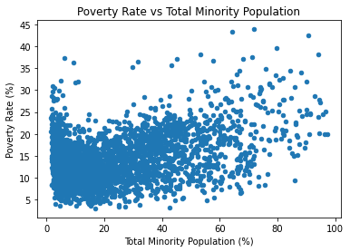

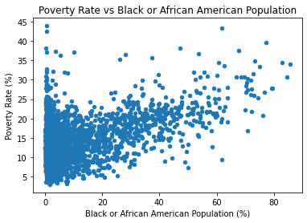

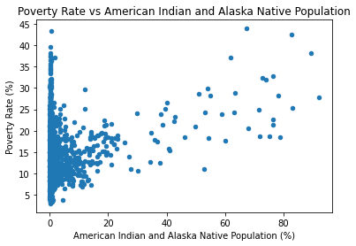

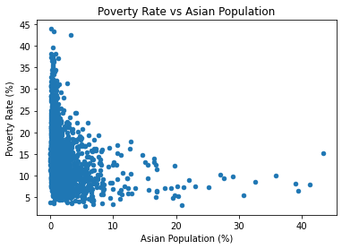

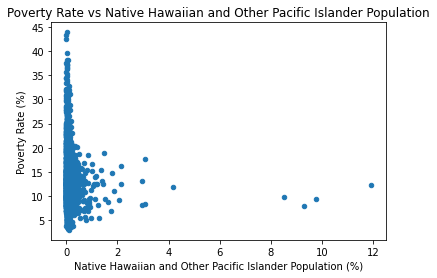

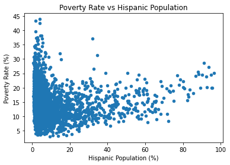

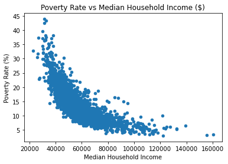

```python
dft.plot.scatter(x="TOT_MINPERC",y="Poverty Percent, All Ages")
plt.xlabel("Total Minority Population (%)")
plt.ylabel("Poverty Rate (%)")
plt.title("Poverty Rate vs Total Minority Population")
plt.show()

dft.plot.scatter(x="NHBA_P",y="Poverty Percent, All Ages")
plt.xlabel("Black or African American Population (%)")
plt.ylabel("Poverty Rate (%)")
plt.title("Poverty Rate vs Black or African American Population")

plt.show()

dft.plot.scatter(x="NHIA_P",y="Poverty Percent, All Ages")
plt.xlabel("American Indian and Alaska Native Population (%)")
plt.ylabel("Poverty Rate (%)")
plt.title("Poverty Rate vs American Indian and Alaska Native Population")
plt.show()

dft.plot.scatter(x="NHAA_P",y="Poverty Percent, All Ages")
plt.xlabel("Asian Population (%)")
plt.ylabel("Poverty Rate (%)")
plt.title("Poverty Rate vs Asian Population")
plt.show()

dft.plot.scatter(x="NHNA_P",y="Poverty Percent, All Ages")
plt.xlabel("Native Hawaiian and Other Pacific Islander Population (%)")
plt.ylabel("Poverty Rate (%)")
plt.title("Poverty Rate vs Native Hawaiian and Other Pacific Islander Population")
plt.show()

dft.plot.scatter(x="H_P",y="Poverty Percent, All Ages")
plt.xlabel("Hispanic Population (%)")
plt.ylabel("Poverty Rate (%)")
plt.title("Poverty Rate vs Hispanic Population")
plt.show()

dft.plot.scatter(x="Median Household Income",y="Poverty Percent, All Ages")
plt.ylabel("Poverty Rate (%)")
plt.title("Poverty Rate vs Median Household Income ($)")
plt.show()
```

Now that we have done some preliminary data analysis, we can dive a little further in depth. We will create a linear regression model to predict a county's poverty percentage. This model will use the population breakdown of different minorities in a county as the independent variables. First, we use the Statsmodels library to fit an OLS regression to the data in order to conduct a hypothesis test.

```python
dft = dft.rename({"Poverty Percent, All Ages": "Poverty_Percent"},axis=1)
dft = dft.dropna()
mod = smf.ols(formula='Poverty_Percent ~ H_P + NHNA_P + NHAA_P + NHIA_P + NHBA_P', data=dft)
res = mod.fit()
print(res.summary())
```

```
                            OLS Regression Results
==============================================================================
Dep. Variable:        Poverty_Percent   R-squared:                       0.400
Model:                            OLS   Adj. R-squared:                  0.399
Method:                 Least Squares   F-statistic:                     418.2
Date:                Wed, 17 May 2023   Prob (F-statistic):               0.00
Time:                        22:47:30   Log-Likelihood:                -8966.9
No. Observations:                3142   AIC:                         1.795e+04
Df Residuals:                    3136   BIC:                         1.798e+04
Df Model:                           5
Covariance Type:            nonrobust
==============================================================================
                 coef    std err          t      P>|t|      [0.025      0.975]
------------------------------------------------------------------------------
Intercept     11.4912      0.114    100.612      0.000      11.267      11.715
H_P            0.0575      0.005     10.477      0.000       0.047       0.068
NHNA_P         0.7174      0.203      3.529      0.000       0.319       1.116
NHAA_P        -0.4670      0.028    -16.468      0.000      -0.523      -0.411
NHIA_P         0.2146      0.010     21.155      0.000       0.195       0.234
NHBA_P         0.2104      0.005     39.471      0.000       0.200       0.221
==============================================================================
Omnibus:                      546.685   Durbin-Watson:                   1.533
Prob(Omnibus):                  0.000   Jarque-Bera (JB):             1350.837
Skew:                           0.961   Prob(JB):                    4.67e-294
Kurtosis:                       5.574   Cond. No.                         51.6
==============================================================================

Notes:
[1] Standard Errors assume that the covariance matrix of the errors is correctly specified.
```

Now, let us use this linear model to look at how the population demographics of a county might predict the poverty rate in that county.

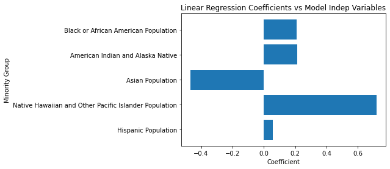

```python
X = dft.loc[:,["H_P", "NHNA_P", "NHAA_P", "NHIA_P", "NHBA_P"]]
y = np.array(dft["Poverty_Percent"])


reg = LinearRegression().fit(X, y)
plt.barh(y=["Hispanic Population","Native Hawaiian and Other Pacific Islander Population","Asian Population","American Indian and Alaska Native","Black or African American Population"], width=reg.coef_)
plt.xlabel("Coefficient")
plt.ylabel("Minority Group")
plt.title("Linear Regression Coefficients vs Model Indep Variables")
plt.show()
```

This plot shows us that every racial deomgraphic except for Asian is positively correlated with a higher poverty rate. Specifically, it appears that a county's native hawaiian and other pacific islander population has a strong effect on that county's poverty rate.

## Step 4: Interpretation and insights

The preliminary analysis, hypothesis testing, and machine learning leave us with some takeaways. Firstly, from the preliminary analysis, we saw that the distribution of minorities in the United States is NOT even. That is to say, there are places with far more minorities both by total number and more importantly by percentage. Secondly, we can say the same about poverty in the United States. It is not evenly distributed. There appears to be at least some wealth inequality at least puerly by geographical location.  
From the hypothesis testing and machine learning we can better connect these two ideas. Our linear model confirmed that there is a statistically significant relationship between a county's demographics and the poverty rate in that county. This is not to say that a county's poverty rate is solely based on the demographic. Rather, from our R squared statistic we can say that a county's poverty rate is around 40% based on the demographic breakdown. While this is not the whole story, it is important to think about why this part of the story can account for so much of the poverty rate.  
The United States is built upon racial inequality and social injustice. This analysis shows to us that these inequalities are still prevelant at least in 2020, and likely today as well. Analyzing the data in order to tease out these trends which demonstrate racial inequality is important for two reasons. It is important because there are still people who deny the existence of these systemic inequalities. In spite of all of the misinformation and fearmongering, it is important to continue to strive to produce accurate and significant statistical analysis using data science. Additionally, it is important because a continuing effor to analyze this data allows policy makers to be adaptive in their efforts to help alleave the inequalities.